# RMSC4002

set seed

```r
set.seed(4002)
working_dir = 'C:\\Users\\s1155102964\\Desktop\\hw\\RMSC4002\\pj\\'
```

parallel processing

```r
library('doParallel')
clust = makeCluster(detectCores())
registerDoParallel(clust)
getDoParWorkers()
```

```
[1] 8
```

required library

```r
library(rpart)
library(quantmod)
library(anytime)
library(lubridate)
library(nnet)
library(rgr)
library(dplyr)
library(rdbnomics)
library(stringr)
library(ggplot2)
library(reshape2)
library(ROCR)
```

label the data and remove the first column since it is NA col explain open = today open price, close = yesterday close price, tmr_price = whether it is going upward or downward

```r
DJI = data.frame(tseries::get.hist.quote(instrument="^DJI",'2010-1-1','2018-12-31'))[,-(2:3)]
```

```
time series starts 2010-01-04
time series ends   2018-12-28
```

```r
DJI_dict = DJI
```

identify whether index will goes up or down compare to end of month price use regex to identify the last day of the month and then do the comparison create a column contains $\frac{\mu}{\sigma^2}$ of the previous 20 days

```r
mon = str_extract(rownames(DJI), '-\\d+-')
mon = str_extract(mon, '\\d+')
for (i in 1:(length(mon)-1)){
  if (i == 1){
    mon[i] = TRUE
  }
  if (mon[i] != mon[i+1]){
    mon[i] = TRUE
  }
  else{
    mon[i] = FALSE
  }
}
mon = as.logical(mon)
mon_tre = DJI[mon,]
mon_tre = na.omit(mon_tre)
for (i in 2:nrow(mon_tre)){
  if (mon_tre[i,2] > mon_tre[i-1,2]){
    mon_tre[i-1,1] = 'UP'
  }
  else{
    mon_tre[i-1,1] = 'DOWN'
  }
}
mon_tre = mon_tre[-nrow(mon_tre),]
DJI = merge(DJI, mon_tre, all = TRUE, by = 0)[,-5]
DJI[,1] = anydate(DJI[,1])

count = 1
for (i in 1:nrow(DJI)){
  if ((DJI[i,1] <= DJI[i+1,1]) & is.na(DJI[i,4]) & (DJI[i,3] < as.numeric(mon_tre[count,2]))){
    DJI[i,4] = 'UP'
  }
  if((DJI[i,1] <= DJI[i+1,1]) & is.na(DJI[i,4]) & (DJI[i,3] > as.numeric(mon_tre[count,2]))){
    DJI[i,4] = 'DOWN'
  }
  if(DJI[i,3] == as.numeric(mon_tre[count,2])){
    count = count+1
  }
  if(count > nrow(mon_tre)){
    break
  }
}
DJI = cbind(DJI, lag(DJI_dict$Close, 1)[1:nrow(DJI)], lag(DJI_dict$Close, 7)[1:nrow(DJI)], lag(DJI_dict$Close, 20)[1:nrow(DJI)])
colnames(DJI)[4] = 'next_month_position'

# develop the attribute of DJI
n = nrow(DJI)
u<-rep(NA,n) # Empty vector
u<-(lag(DJI_dict$Close)-DJI_dict$Close)/DJI_dict$Close # daily percentage change of closing price
mu<-rep(NA,n) # Empty vector
sigma<-rep(NA,n) # Empty vector
for (iDate in 21:n){ # Pointer of date
  mu[iDate]<-mean(DJI$Close[(iDate-20):iDate]) # mean of closing price in before 20 days
  sigma[iDate]<-sd(DJI$Close[(iDate-20):iDate]) # standard deviation of closing price in recent 20 days
}
mos<-mu/sigma^2 # mean over sigma square
DJI = cbind(DJI, mos)
```

volume, highest price, lowest price of DJI

```r
DJI_vol = data.frame(tseries::get.hist.quote(instrument="^DJI",'2010-1-1','2018-12-31', quote = 'Volume'))
```

```
time series starts 2010-01-04
time series ends   2018-12-28
```

```r
DJI_vol = apply(DJI_vol, 2, lag)
DJI_high_low = tseries::get.hist.quote(instrument="^DJI",'2010-1-1','2018-12-31', quote = c('High', 'Low'))
```

```
time series starts 2010-01-04
time series ends   2018-12-28
```

```r
DJI_high_low = apply(DJI_high_low, 2, lag)
DJI[,3] = lag(DJI[,3])
DJI = cbind(DJI, DJI_vol, DJI_high_low)
DJI = DJI[,-1]
```

other index’s data include volume ,highest price, lowest price, open and closing price (GSPC, IXIC, RUT, VIX) note that data of VIX’s volume doesn’t exist lag the high, low, and close price 1 day after create a column contains $\frac{\mu}{\sigma^2}$ of the previous 20 days of each index

```r
GSPC = data.frame(tseries::get.hist.quote(instrument="^GSPC",'2010-1-1','2018-12-31', quote = c("Open", "High", "Low", "Close", "Volume")))
```

```
time series starts 2010-01-04
time series ends   2018-12-28
```

```r
IXIC = data.frame(tseries::get.hist.quote(instrument="^IXIC",'2010-1-1','2018-12-31', quote = c("Open", "High", "Low", "Close", "Volume")))
```

```
time series starts 2010-01-04
time series ends   2018-12-28
```

```r
RUT = data.frame(tseries::get.hist.quote(instrument="^RUT",'2010-1-1','2018-12-31', quote = c("Open", "High", "Low", "Close", "Volume")))
```

```
time series starts 2010-01-04
time series ends   2018-12-28
```

```r
VIX = data.frame(tseries::get.hist.quote(instrument="^VIX",'2010-1-1','2018-12-31', quote = c("Open", "High", "Low", "Close")))
```

```
time series starts 2010-01-04
time series ends   2018-12-28
```

```r
index = cbind(GSPC, IXIC, RUT, VIX)
close = Cl(index)
u<-matrix(NA,nr=n,nc=ncol(close)) # Empty matrix
mu<-matrix(NA,nr=n,nc=ncol(close)) # Empty matrix
sigma<-matrix(NA,nr=n,nc=ncol(close)) # Empty matrix
mos<-matrix(NA,nr=n,nc=ncol(close)) # Empty matrix
for (jStock in 1:ncol(close)){
  u[,jStock]<-(lag(close[,jStock])-close[,jStock])/close[,jStock] # daily percentage of closing price in jStock
  for (iDate in 21:n){ # Pointer of date
    mu[iDate,jStock]<-mean(close[(iDate-20):iDate,jStock]) # mean of closing price in before 20 days
    sigma[iDate,jStock]<-sd(close[(iDate-20):iDate,jStock]) # standard deviation of closing price in recent 20 days
  }
  mos[,jStock]<-mu[,jStock]/sigma[,jStock]^2 # mean over sigma square
}
GSPC[,2:5] = apply(GSPC[,2:5], 2, lag)
IXIC[,2:5] = apply(IXIC[,2:5], 2, lag)
RUT[,2:5] = apply(RUT[,2:5], 2, lag)
VIX[,2:4] = apply(VIX[,2:4], 2, lag)
colnames(mos) = paste('mos', 1:4, sep = '_')
index = cbind(GSPC, IXIC, RUT, VIX, mos)
```

The 30 stocks that include in DJI index some stocks may not be contained as they are already not in the index list and some new stock joined

```r
AAPL = data.frame(tseries::get.hist.quote(instrument="AAPL",'2010-1-1','2018-12-31', quote = c("Open", "High", "Low", "Close", "Volume")))
```

```
time series starts 2010-01-04
time series ends   2018-12-28
```

```r
AXP = data.frame(tseries::get.hist.quote(instrument="AXP",'2010-1-1','2018-12-31', quote = c("Open", "High", "Low", "Close", "Volume")))
```

```
time series starts 2010-01-04
time series ends   2018-12-28
```

```r
BA = data.frame(tseries::get.hist.quote(instrument="BA",'2010-1-1','2018-12-31', quote = c("Open", "High", "Low", "Close", "Volume")))
```

```
time series starts 2010-01-04
time series ends   2018-12-28
```

```r
CAT = data.frame(tseries::get.hist.quote(instrument="CAT",'2010-1-1','2018-12-31', quote = c("Open", "High", "Low", "Close", "Volume")))
```

```
time series starts 2010-01-04
time series ends   2018-12-28
```

```r
CSCO = data.frame(tseries::get.hist.quote(instrument="CSCO",'2010-1-1','2018-12-31', quote = c("Open", "High", "Low", "Close", "Volume")))
```

```
time series starts 2010-01-04
time series ends   2018-12-28
```

```r
CVX = data.frame(tseries::get.hist.quote(instrument="CVX",'2010-1-1','2018-12-31', quote = c("Open", "High", "Low", "Close", "Volume")))
```

```
time series starts 2010-01-04
time series ends   2018-12-28
```

```r
DIS = data.frame(tseries::get.hist.quote(instrument="DIS",'2010-1-1','2018-12-31', quote = c("Open", "High", "Low", "Close", "Volume")))
```

```
time series starts 2010-01-04
time series ends   2018-12-28
```

```r
GS = data.frame(tseries::get.hist.quote(instrument="GS",'2010-1-1','2018-12-31', quote = c("Open", "High", "Low", "Close", "Volume")))
```

```
time series starts 2010-01-04
time series ends   2018-12-28
```

```r
HD = data.frame(tseries::get.hist.quote(instrument="HD",'2010-1-1','2018-12-31', quote = c("Open", "High", "Low", "Close", "Volume")))
```

```
time series starts 2010-01-04
time series ends   2018-12-28
```

```r
IBM = data.frame(tseries::get.hist.quote(instrument="IBM",'2010-1-1','2018-12-31', quote = c("Open", "High", "Low", "Close", "Volume")))
```

```
time series starts 2010-01-04
time series ends   2018-12-28
```

```r
INTC = data.frame(tseries::get.hist.quote(instrument="INTC",'2010-1-1','2018-12-31', quote = c("Open", "High", "Low", "Close", "Volume")))
```

```
time series starts 2010-01-04
time series ends   2018-12-28
```

```r
JNJ = data.frame(tseries::get.hist.quote(instrument="JNJ",'2010-1-1','2018-12-31', quote = c("Open", "High", "Low", "Close", "Volume")))
```

```
time series starts 2010-01-04
time series ends   2018-12-28
```

```r
JPM = data.frame(tseries::get.hist.quote(instrument="JPM",'2010-1-1','2018-12-31', quote = c("Open", "High", "Low", "Close", "Volume")))
```

```
time series starts 2010-01-04
time series ends   2018-12-28
```

```r
KO = data.frame(tseries::get.hist.quote(instrument="KO",'2010-1-1','2018-12-31', quote = c("Open", "High", "Low", "Close", "Volume")))
```

```
time series starts 2010-01-04
time series ends   2018-12-28
```

```r
MCD = data.frame(tseries::get.hist.quote(instrument="MCD",'2010-1-1','2018-12-31', quote = c("Open", "High", "Low", "Close", "Volume")))
```

```
time series starts 2010-01-04
time series ends   2018-12-28
```

```r
MMM = data.frame(tseries::get.hist.quote(instrument="MMM",'2010-1-1','2018-12-31', quote = c("Open", "High", "Low", "Close", "Volume")))
```

```
time series starts 2010-01-04
time series ends   2018-12-28
```

```r
MRK = data.frame(tseries::get.hist.quote(instrument="MRK",'2010-1-1','2018-12-31', quote = c("Open", "High", "Low", "Close", "Volume")))
```

```
time series starts 2010-01-04
time series ends   2018-12-28
```

```r
MSFT = data.frame(tseries::get.hist.quote(instrument="MSFT",'2010-1-1','2018-12-31', quote = c("Open", "High", "Low", "Close", "Volume")))
```

```
time series starts 2010-01-04
time series ends   2018-12-28
```

```r
NKE = data.frame(tseries::get.hist.quote(instrument="NKE",'2010-1-1','2018-12-31', quote = c("Open", "High", "Low", "Close", "Volume")))
```

```
time series starts 2010-01-04
time series ends   2018-12-28
```

```r
PFE = data.frame(tseries::get.hist.quote(instrument="PFE",'2010-1-1','2018-12-31', quote = c("Open", "High", "Low", "Close", "Volume")))
```

```
time series starts 2010-01-04
time series ends   2018-12-28
```

```r
NKE = data.frame(tseries::get.hist.quote(instrument="NKE",'2010-1-1','2018-12-31', quote = c("Open", "High", "Low", "Close", "Volume")))
```

```
time series starts 2010-01-04
time series ends   2018-12-28
```

```r
PG = data.frame(tseries::get.hist.quote(instrument="PG",'2010-1-1','2018-12-31', quote = c("Open", "High", "Low", "Close", "Volume")))
```

```
time series starts 2010-01-04
time series ends   2018-12-28
```

```r
TRV = data.frame(tseries::get.hist.quote(instrument="TRV",'2010-1-1','2018-12-31', quote = c("Open", "High", "Low", "Close", "Volume")))
```

```
time series starts 2010-01-04
time series ends   2018-12-28
```

```r
UNH = data.frame(tseries::get.hist.quote(instrument="UNH",'2010-1-1','2018-12-31', quote = c("Open", "High", "Low", "Close", "Volume")))
```

```
time series starts 2010-01-04
time series ends   2018-12-28
```

```r
UTX = data.frame(tseries::get.hist.quote(instrument="UTX",'2010-1-1','2018-12-31', quote = c("Open", "High", "Low", "Close", "Volume")))
```

```
time series starts 2010-01-04
time series ends   2018-12-28
```

```r
VZ = data.frame(tseries::get.hist.quote(instrument="VZ",'2010-1-1','2018-12-31', quote = c("Open", "High", "Low", "Close", "Volume")))
```

```
time series starts 2010-01-04
time series ends   2018-12-28
```

```r
WBA = data.frame(tseries::get.hist.quote(instrument="WBA",'2010-1-1','2018-12-31', quote = c("Open", "High", "Low", "Close", "Volume")))
```

```
time series starts 2010-01-04
time series ends   2018-12-28
```

```r
WMT = data.frame(tseries::get.hist.quote(instrument="WMT",'2010-1-1','2018-12-31', quote = c("Open", "High", "Low", "Close", "Volume")))
```

```
time series starts 2010-01-04
time series ends   2018-12-28
```

```r
XOM = data.frame(tseries::get.hist.quote(instrument="XOM",'2010-1-1','2018-12-31', quote = c("Open", "High", "Low", "Close", "Volume")))
```

```
time series starts 2010-01-04
time series ends   2018-12-28
```

```r
stock = cbind.data.frame(AAPL, AXP, BA, CAT, CSCO, CVX, DIS, GS, HD, IBM, INTC, JNJ, JPM, KO, MCD, MMM, MRK, MSFT, NKE, PFE, PG, TRV, UNH, UTX, VZ, WBA, WMT, XOM)

open = Op(stock)
close = Cl(stock)
low = Lo(stock)
high = Hi(stock)
volume = Vo(stock)
u<-matrix(NA,nr=n,nc=ncol(close)) # Empty matrix
mu<-matrix(NA,nr=n,nc=ncol(close)) # Empty matrix
sigma<-matrix(NA,nr=n,nc=ncol(close)) # Empty matrix
mos<-matrix(NA,nr=n,nc=ncol(close)) # Empty matrix
for (jStock in 1:ncol(close)){
  u[,jStock]<-(lag(close[,jStock])-close[,jStock])/close[,jStock] # daily percentage of closing price in jStock
  for (iDate in 21:n){ # Pointer of date
    mu[iDate,jStock]<-mean(close[(iDate-20):iDate,jStock]) # mean of closing price in before 20 days
    sigma[iDate,jStock]<-sd(close[(iDate-20):iDate,jStock]) # standard deviation of closing price in recent 20 days
  }
  mos[,jStock]<-mu[,jStock]/sigma[,jStock]^2 # mean over sigma square
}
colnames(mos) = paste('mos', 1:ncol(mos), sep = '_')
close = apply(Cl(stock), 2, lag)
high = apply(Hi(stock), 2, lag)
low = apply(Lo(stock), 2, lag)
volume = apply(Vo(stock), 2 ,lag)
stock = cbind.data.frame(open, close, high, low, volume, mos)
```

combine all df together and omit all NAs remove todays close price since we cannot get today’s close price in reality

```r
DJI_df = cbind(DJI, index, stock, deparse.level = 1)
DJI_df = na.omit(DJI_df)
DJI_df$next_month_position = as.factor(DJI_df$next_month_position)
```

scale the data by the formula $x'=\frac{x-min}{max-min}$

```r
scaled_DJI = DJI_df
for (i in 1:2) scaled_DJI[,i] = (DJI_df[,i]-min(DJI_df[,i]))/(max(DJI_df[,i])-min(DJI_df[,i]))
for (i in 4:ncol(scaled_DJI)) scaled_DJI[,i] = (DJI_df[,i]-min(DJI_df[,i]))/(max(DJI_df[,i])-min(DJI_df[,i]))
scaled_DJI = na.omit(scaled_DJI)
```

copy the ANN for loop from lecture notes

```r
ann<-function(x,y,size,maxit=100,linout=F,try=10, MaxNWts =1000000) {
ann1<-nnet(y~.,data=x,size=size,maxit=maxit,linout=linout, MaxNWts =1000000)
v1<-ann1$value # save the value for the first trial
for (i in 2:try) {
ann<-nnet(y~.,data=x,size=size,maxit=maxit,linout=linout, MaxNWts =1000000)
if (ann$value<v1) { # check if the current value is better
v1<-ann$value # save the best value
ann1<-ann # save the results
}
}
ann1 # return the results
}
```

a demo that listed in the report showing that how good is the data fit in the classification problem

```r
ann_size11_demo = ann(scaled_DJI[,-3], scaled_DJI[,3] , size = 11, maxit = 200, try = 2)
```

seperate train and test data the reason of defining 1:201 is to solve the bug from R

```r
test = sample(1:nrow(DJI), nrow(DJI)*0.2)
test_x = na.omit(scaled_DJI[test,(1:201)])
train_x = na.omit(scaled_DJI[-test,(1:201)])
```

A demo of ANN predicting ability on classification problem and the a ROC curve is ploted AUC is also found

```r
ann_size11_demo = ann(train_x[,-3], train_x[,3] , size = 2, maxit = 200, try = 2)
pred_freq = predict(ann_size11_demo, test_x)
pred = ifelse(pred_freq > 0.5, 'Up', 'Down')
tab = table(pred, test_x[,3])
(tab[1,1] + tab[2,2])/(tab[1,1] + tab[1,2] + tab[2,1] + tab[2,2])
```

```
[1] 0.69161
```

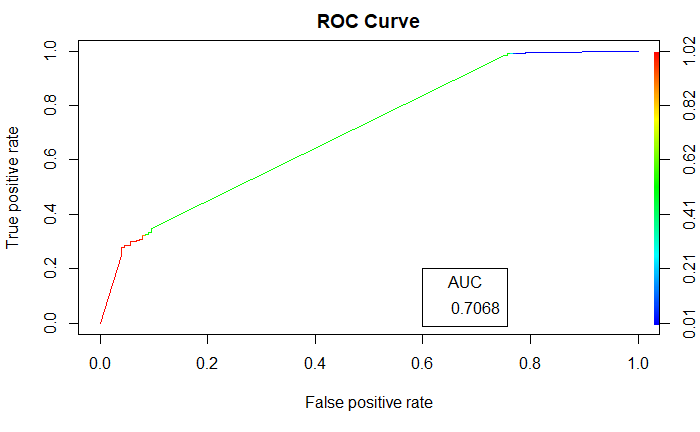

```r
pred_wif_pred = prediction(pred_freq, test_x[,3])
roc = performance(pred_wif_pred, 'tpr', 'fpr')
plot(roc, colorize = T, main = 'ROC Curve')
auc = performance(pred_wif_pred, 'auc')
auc = unlist(slot(auc, 'y.values'))
auc = round(auc, 4)
legend(0.6, 0.2, auc, title = 'AUC')
```

a function that find the best performed ANN on each size of hidden layer confusion matrix of the best model of that particular size of hidden will be return the respective distribution and accuracy and all accuracy during the model selection will also be include

```r
max_accruacy_ann = function(x,y,size,maxit=100,linout=F, test_x, try, MaxNWts =1000000) {
    ann_min = nnet(y~.,data=x,size=size,maxit=maxit,linout=linout, MaxNWts =1000000)
    best_pred = predict(ann_min, test_x)
    pred4tab = ifelse(best_pred > 0.5, 'Up', 'Down')
    tab = table(pred4tab, test_x[,3])
    accruacy = sum(diag(tab))/sum(tab)
    cum_acc = c(accruacy)
    for (i in 2:try){
      ann_min = nnet(y~.,data=x,size=size,maxit=maxit,linout=linout, MaxNWts =1000000)
      pred = predict(ann_min, test_x)
      pred4tab = ifelse(pred > 0.5, 'Up', 'Down')
      tab_new = table(pred4tab, test_x[,3])
      accruacy_new = sum(diag(tab_new))/sum(tab_new)
      cum_acc = append(cum_acc, accruacy_new)
      if (accruacy < accruacy_new){
        accruacy = accruacy_new
        best_pred = pred
        tab = tab_new
    }
    }
    return(list(tab, best_pred, accruacy, cum_acc))
}
```

train the model and find the variance, maximum, minimum, q1, q2, q3 of the accruacy of each size of hidden layer an accuracy table will be produce

```r
classification = list()
for (i in 2:4){
  classification[[i]] = max_accruacy_ann(train_x[,-3], train_x[,3] , size = i, maxit = 200, try = 12, test_x = test_x)

}
cum_accruacy = list()
for (i in 2:4) cum_accruacy[i-1] = as.vector(classification[[i]][4])
acc_mat = matrix(NA, ncol = 11, nrow = 7)
for(i in 1:3) acc_mat[,i] = rbind(mean(cum_accruacy[[i]]),
  var(cum_accruacy[[i]]),
  max(cum_accruacy[[i]]),
  min(cum_accruacy[[i]]),
  quantile(cum_accruacy[[i]], 0.25),
  median(cum_accruacy[[i]]),
  quantile(cum_accruacy[[i]], 0.75))
  rownames(acc_mat) = c('mean', 'var', 'max', 'min', 'q1', 'q2', 'q3')
  colnames(acc_mat) = paste('size', 2:12, sep = '_')
  write.csv(acc_mat, file = paste0(working_dir, 'accruacy_table.csv'))
```

Data will be use for predict the actual price Basically there is no difference same process with the initial approach split the data into train and test data

```r
DJI = merge(DJI_dict, mon_tre, all = TRUE, by = 0)[,-4]
for (i in 1:(nrow(DJI_dict)-1)){
  if ((DJI[i,1] < DJI[i+1,1]) & is.na(DJI[i+1,4])){
    DJI[i+1,4] = DJI[i,4]
  }
}
colnames(DJI)[4] = 'end_of_month_price'
DJI = cbind(DJI, lag(DJI_dict$Close, 1)[1:nrow(DJI)], lag(DJI_dict$Close, 7)[1:nrow(DJI)], lag(DJI_dict$Close, 20)[1:nrow(DJI)])
DJI = cbind(DJI, mos, DJI_vol, DJI_high_low)
DJI_df = cbind(DJI, index, stock, deparse.level = 1)
DJI_df = na.omit(DJI_df)
DJI_df = DJI_df[,c(-1,-3)]
scaled_DJI = DJI_df
for (i in 1:ncol(scaled_DJI)) scaled_DJI[,i] = (DJI_df[,i]-min(DJI_df[,i]))/(max(DJI_df[,i])-min(DJI_df[,i]))
for (i in 3:ncol(scaled_DJI)) scaled_DJI[,i] = (DJI_df[,i]-min(DJI_df[,i]))/(max(DJI_df[,i])-min(DJI_df[,i]))
scaled_DJI = na.omit(scaled_DJI)
train = 1:round(nrow(scaled_DJI)*0.8)
test_x = scaled_DJI[-train,]
train_x = scaled_DJI[train,]
```

setup a for loop to figure our the least error model

```r
min_error_ann = function(x,y,size,maxit=100,linout=F, test_x, try, MaxNWts =1000000) {
    ann_min = nnet(y~.,data=x,size=size,maxit=maxit,linout=linout, MaxNWts =1000000)
    best_pred = predict(ann_min, test_x)
    error = sum(abs(best_pred - test_x[,2]))
    cum_error = c(error)
    for (i in 2:try){
      ann_min = nnet(y~.,data=x,size=size,maxit=maxit,linout=linout, MaxNWts =1000000)
      pred_price = predict(ann_min, test_x)
      error_new = sum(abs(pred_price - test_x[,2]))
      cum_error = append(cum_error, error_new)
    if (error_new < error){
      error = error_new
      best_pred = pred_price
    }
    }
    return(list(error, cum_error, best_pred))
}
```

a demo on show how good fit is the data on predicting the actual price

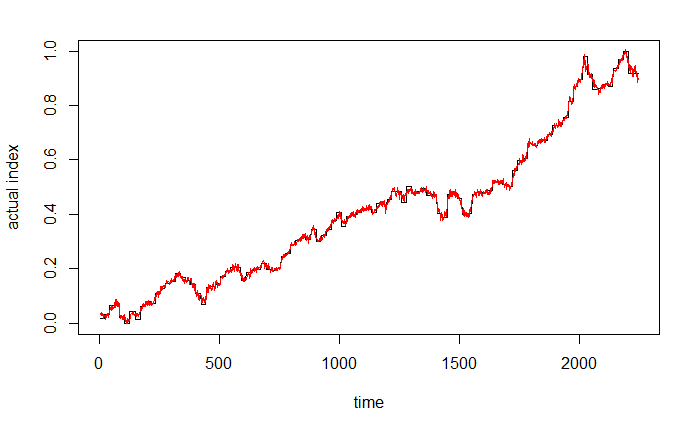

```r
ann_price_fit_performance = ann(scaled_DJI[,-2], scaled_DJI[,2] , size = 2, maxit = 200, try = 5, linout = T)
fit = predict(ann_price_fit_performance, scaled_DJI)
error = sum(abs(fit - scaled_DJI[,2]))
unstand = function(x_dash){
  x = x_dash*(max(DJI_df[,2])-min(DJI_df[,2]))+min(DJI_df[,2])
  return(x)
}
stand_price = unstand(error)
plot(scaled_DJI[,2], type = 'l', ylab = 'actual index', xlab = 'time')
lines(fit, col = 'red')
```

```r
err_mat
```

[output not shown]

```
       size_2    size_3     size_4 size_5 size_6 size_7 size_8 size_9 size_10
mean 155.8023  124.7119  140.92936     NA     NA     NA     NA     NA      NA
var  440.1367 1041.4137 1122.50731     NA     NA     NA     NA     NA      NA
max  202.8149  172.4945  188.13078     NA     NA     NA     NA     NA      NA
min  117.8459   80.1548   69.95795     NA     NA     NA     NA     NA      NA
q1   143.5322  101.6561  120.93578     NA     NA     NA     NA     NA      NA
q2   157.0346  118.0551  151.36941     NA     NA     NA     NA     NA      NA
q3   163.8208  156.4668  156.32600     NA     NA     NA     NA     NA      NA
     size_11 size_12
mean      NA      NA
var       NA      NA
max       NA      NA
min       NA      NA
q1        NA      NA
q2        NA      NA
q3        NA      NA
```

unstandardize the data by $x=x'(max-min)+min$ the below code choose the the predicted price of a size 2 layer

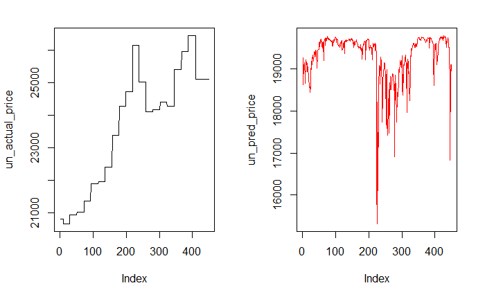

```r
unstand = function(x_dash){
  x = x_dash*(max(DJI_df[,2])-min(DJI_df[,2]))+min(DJI_df[,2])
  return(x)
}
un_pred_price = unstand(compare_list[[2]][[3]])
un_actual_price = unstand(test_x[,2])
compare = cbind.data.frame(un_pred_price, un_actual_price)
par(mfrow = c(1,2))
plot(un_actual_price, type = 'l')
plot(un_pred_price, , type = 'l', col = 'red')
```

[output not shown]